# Loan Approval Optimization: Re-evaluating Automatic Denials

Team 2

2026-02-25

# Executive Summary

# M1: Business Understanding

**The Problem:** The strict business rule (decision tree outcome) automatically denies the 22,858 people who have a prior default. Because this criterion universally drove denial in historic data, any model trained naively on the full dataset learns this as an unbreakable rule. **The Question:** How can we identify credit-worthy applicants among those with a prior default to refer them for secondary, manual review, thereby increasing overall revenue without disproportionately raising default risk? **The Solution Path:** Because historical data contains zero approvals for the “Prior Default” target group, we will utilize **Proxy Target Modeling**. We will train an algorithm *exclusively* on applicants with no prior defaults to understand what a “good” applicant looks like, and then apply this scoring mechanism back to the “Prior Default” group to identify strong candidates for reconsideration.

```r
# Install and load standard project libraries
required_packages <- c(
  "tidyverse", "janitor", "skimr", "GGally",
  "caret", "randomForest", "pROC", "rpart", "rpart.plot", "factoextra", "cluster", "e1071"
)

installed <- rownames(installed.packages())
to_install <- setdiff(required_packages, installed)
if (length(to_install) > 0) install.packages(to_install, quietly = TRUE)

invisible(lapply(required_packages, library, character.only = TRUE))
set.seed(42) # For reproducibility
```

# M2: Data Understanding & Preparation

## 2.1 Load & Initial Structure Check

We load the primary dataset from the `raw` directory and normalize column names.

```r
data_path <- "data/raw/loan_data.csv"
if (!file.exists(data_path)) stop("Data file not found at data/raw/loan_data.csv.")

df_raw <- read_csv(data_path, show_col_types = FALSE) %>% clean_names()

cat("Initial Data Set Dimensions: \nRows:", nrow(df_raw), "\nColumns:", ncol(df_raw), "\n")
```

```
## Initial Data Set Dimensions:
## Rows: 45000
## Columns: 14
```

## 2.2 Data Cleaning & Type Formatting

We apply necessary business rules to handle impossibly high or low values, normalize categories, and handle missing limits explicitly.

```r
df_clean <- df_raw %>%
  dplyr::select(-loan_int_rate) %>%  # <============iteration 1 ======== remove the leakage from loan interest rate
    # Factors & Categories
  mutate(
    person_gender = factor(person_gender),
    person_education = factor(person_education),
    person_home_ownership = factor(person_home_ownership),
    loan_intent = factor(loan_intent),
    previous_loan_defaults_on_file = factor(previous_loan_defaults_on_file),
    loan_status = factor(loan_status, levels = c(0, 1), labels = c("Denied", "Approved")),

    # Integer fixes
    person_age = as.integer(ifelse(person_age < 18 | person_age > 100, NA, person_age)),
    person_emp_exp = as.integer(ifelse(person_emp_exp < 0 | person_emp_exp > 60, NA, person_emp_exp)),
    cb_person_cred_hist_length = as.integer(ifelse(cb_person_cred_hist_length < 0 | cb_person_cred_hist_length > 60, NA, cb_person_cred_hist_length)),
    credit_score = as.integer(ifelse(credit_score < 300 | credit_score > 850, NA, credit_score)),

    # Financial metricssanitization=============================Iteration 2!===================
    #loan_int_rate = ifelse(loan_int_rate < 0 | loan_int_rate > 60, NA, loan_int_rate),
    loan_percent_income = ifelse(loan_percent_income <= 0 | loan_percent_income > 1.5, NA, loan_percent_income),
    person_income = ifelse(person_income <= 0, NA, person_income),
    loan_amnt = ifelse(loan_amnt <= 0, NA, loan_amnt),
    #===========================Iteration2============================
    # 1. Financial Maturity: How much of their life have they had #credit?
    credit_to_age_ratio = cb_person_cred_hist_length / person_age,

    # 2. Income Stability: Income relative to years of employment (+1 #avoids division by zero)
    income_per_year_emp = person_income / (person_emp_exp + 1),

    # 3. Loan-to-Credit-Score Proxy: Balances the ask against their reputation
    loan_to_score_ratio = loan_amnt / credit_score

  )

# Drop missing targets and key variables to ensure modeled data is completely sound
df_clean <- df_clean %>%
  drop_na()

cat("Valid Rows after Business Rules & NAs removed:", nrow(df_clean), "\n")
```

```
## Valid Rows after Business Rules & NAs removed: 44966
```

## 2.3 The “Base Case 1” Data Split

Here, we perform the crucial logical split. We isolate the “Prior Default” group (the excluded population) from the “No Prior Default” group (the training population).

```r
# The Training & Evaluation Group (No Defaults)
df_no_default <- df_clean %>% filter(previous_loan_defaults_on_file == "No")

# The "Holdout" Action Group (Prior Defaults)
df_with_default <- df_clean %>% filter(previous_loan_defaults_on_file == "Yes")

cat("No Prior Default (Train/Test Population):", nrow(df_no_default), "\n")
```

```
## No Prior Default (Train/Test Population): 22125
```

```r
cat("Prior Default (To Be Scored Later):", nrow(df_with_default), "\n")
```

```
## Prior Default (To Be Scored Later): 22841
```

### Exploratory Overlap (The Business Case Evidence)

Let’s visually prove the core business hypothesis: many prior defaulters possess equal or better credit health than currently approved individuals.

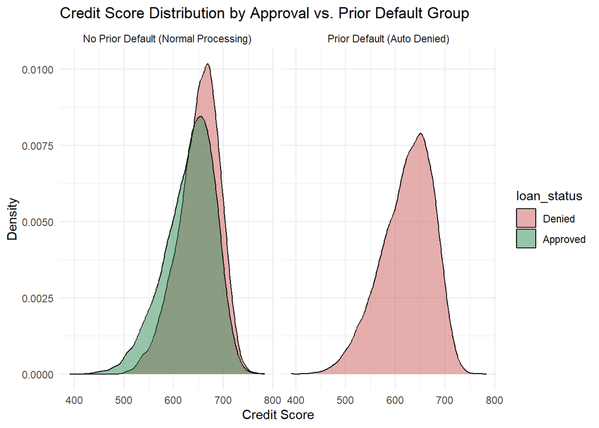

```r
p1 <- ggplot(df_clean, aes(x = credit_score, fill = loan_status)) +
  geom_density(alpha = 0.5) +
  facet_wrap(~previous_loan_defaults_on_file, labeller = as_labeller(c("No" = "No Prior Default (Normal Processing)", "Yes" = "Prior Default (Auto Denied)"))) +
  scale_fill_manual(values = c("indianred", "seagreen")) +
  theme_minimal() +
  labs(
    title = "Credit Score Distribution by Approval vs. Prior Default Group",
    x = "Credit Score", y = "Density"
  )

print(p1)
```

# M3: Modeling

## 3.1 Proxy Target Approach Setup

We will train our classification models strictly on `df_no_default` to map typical approval standards without the bias of the absolute denial rule enforced on prior defaulters.

```r
# Stratified Train/Test split on the No-Default population
idx <- caret::createDataPartition(df_no_default$loan_status, p = 0.8, list = FALSE)
train_set <- df_no_default[idx, ] %>% dplyr::select(-previous_loan_defaults_on_file) # remove from predictors
test_set <- df_no_default[-idx, ] %>% dplyr::select(-previous_loan_defaults_on_file)
```

## 3.2 Interpretable Model Baseline (Decision Tree)

We start with a transparent tree to understand which features weigh heaviest in the “normal” approval process.

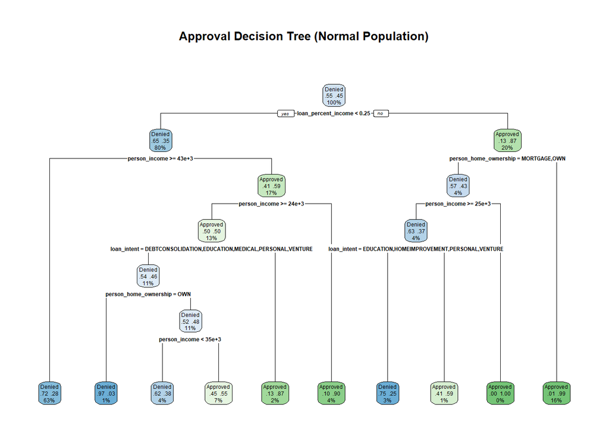

```r
tree_model <- rpart(
  loan_status ~ .,
  data = train_set,
  method = "class",
  control = rpart.control(cp = 0.005)
)

rpart.plot(tree_model, type = 2, extra = 104, fallen.leaves = TRUE, main = "Approval Decision Tree (Normal Population)")
```

## 3.3 High-Performance Model (Random Forest)

A more robust Random Forest model will better capture the non-linear boundaries of approval criteria.

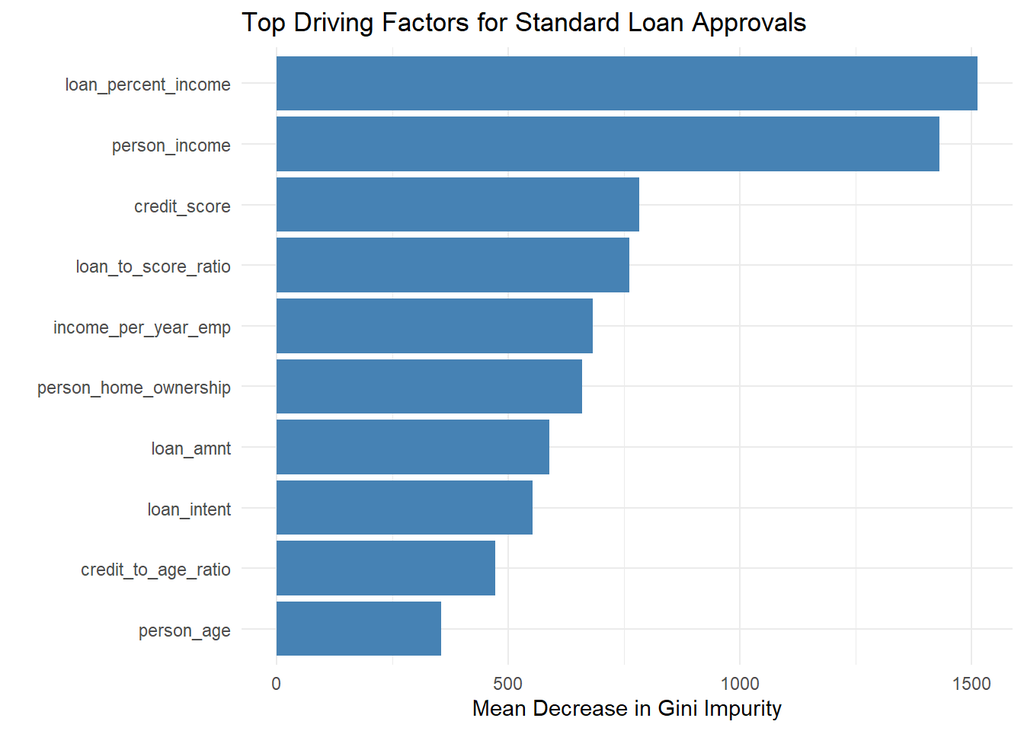

```r
rf_model <- randomForest(
  loan_status ~ .,
  data = train_set,
  ntree = 200,
  importance = TRUE
)

# Feature Importance
imp <- importance(rf_model)
imp_df <- tibble(feature = rownames(imp), MeanDecreaseGini = imp[, "MeanDecreaseGini"]) %>%
  arrange(desc(MeanDecreaseGini)) %>%
  head(10)

ggplot(imp_df, aes(x = reorder(feature, MeanDecreaseGini), y = MeanDecreaseGini)) +
  geom_col(fill = "steelblue") +
  coord_flip() +
  theme_minimal() +
  labs(title = "Top Driving Factors for Standard Loan Approvals", x = "", y = "Mean Decrease in Gini Impurity")
```

## 3.4 Support Vector Machine (SVM)

```r
# Start with a linear kernel SVM
model_svm <- svm(
  loan_status ~ .,
  data = train_set,
  kernel = "linear",
  cost = 0.1
)

# Predict on test set
predicted_svm <- predict(model_svm, test_set, decision.values = TRUE)
test_set$svm_pred_class <- predicted_svm
test_set$svm_dv <- as.numeric(attr(predicted_svm, "decision.values"))
```

## 3.5 Logistic Regression

```r
logit_model <- glm(
  loan_status ~ .,
  family = "binomial",
  data = train_set
)
summary(logit_model)
```

```
##
## Call:
## glm(formula = loan_status ~ ., family = "binomial", data = train_set)
##
## Coefficients:
##                               Estimate Std. Error z value Pr(>|z|)
## (Intercept)                  4.518e+00  5.519e-01   8.187 2.68e-16 ***
## person_age                  -1.004e-02  1.301e-02  -0.772 0.440328
## person_gendermale            1.343e-02  3.609e-02   0.372 0.709764
## person_educationBachelor     3.196e-02  4.803e-02   0.665 0.505818
## person_educationDoctorate    9.652e-02  1.519e-01   0.635 0.525258
## person_educationHigh School  4.696e-02  5.001e-02   0.939 0.347717
## person_educationMaster       8.595e-02  5.730e-02   1.500 0.133590
## person_income                1.817e-06  5.398e-07   3.366 0.000762 ***
## person_emp_exp              -2.599e-02  1.104e-02  -2.353 0.018621 *
## person_home_ownershipOTHER   5.644e-01  3.136e-01   1.800 0.071870 .
## person_home_ownershipOWN    -1.226e+00  1.063e-01 -11.535  < 2e-16 ***
## person_home_ownershipRENT    8.637e-01  4.059e-02  21.277  < 2e-16 ***
## loan_amnt                   -3.521e-05  3.675e-05  -0.958 0.337916
## loan_intentEDUCATION        -9.428e-01  5.982e-02 -15.759  < 2e-16 ***
## loan_intentHOMEIMPROVEMENT  -6.590e-02  6.608e-02  -0.997 0.318651
## loan_intentMEDICAL          -2.423e-01  5.709e-02  -4.245 2.19e-05 ***
## loan_intentPERSONAL         -7.311e-01  6.086e-02 -12.013  < 2e-16 ***
## loan_intentVENTURE          -1.125e+00  6.466e-02 -17.394  < 2e-16 ***
## loan_percent_income          1.329e+01  3.902e-01  34.060  < 2e-16 ***
## cb_person_cred_hist_length   1.155e-01  3.405e-02   3.393 0.000693 ***
## credit_score                -8.908e-03  7.043e-04 -12.647  < 2e-16 ***
## credit_to_age_ratio         -3.737e+00  9.966e-01  -3.750 0.000177 ***
## income_per_year_emp         -3.998e-06  1.016e-06  -3.935 8.31e-05 ***
## loan_to_score_ratio         -1.771e-02  2.318e-02  -0.764 0.444986
## ---
## Signif. codes:  0 '***' 0.001 '**' 0.01 '*' 0.05 '.' 0.1 ' ' 1
##
## (Dispersion parameter for binomial family taken to be 1)
##
##     Null deviance: 24375  on 17700  degrees of freedom
## Residual deviance: 18588  on 17677  degrees of freedom
## AIC: 18636
##
## Number of Fisher Scoring iterations: 4
```

```r
# Predict probabilities on test set
test_set$logit_pred_prob <- predict(logit_model, test_set, type = "response")
test_set$logit_pred_class <- factor(ifelse(test_set$logit_pred_prob > 0.5, "Approved", "Denied"), levels = c("Denied", "Approved"))
```

# M4: Model Validation & Model Tuning

For many machine learning problems, simply running a model out-of-the-box and getting a prediction is not enough; you want the best model with the most accurate prediction. We will optimize the settings for specific models before projecting them to the denied population.

## 4.1 Classification Tree Model Tuning

### k-fold Cross-validation

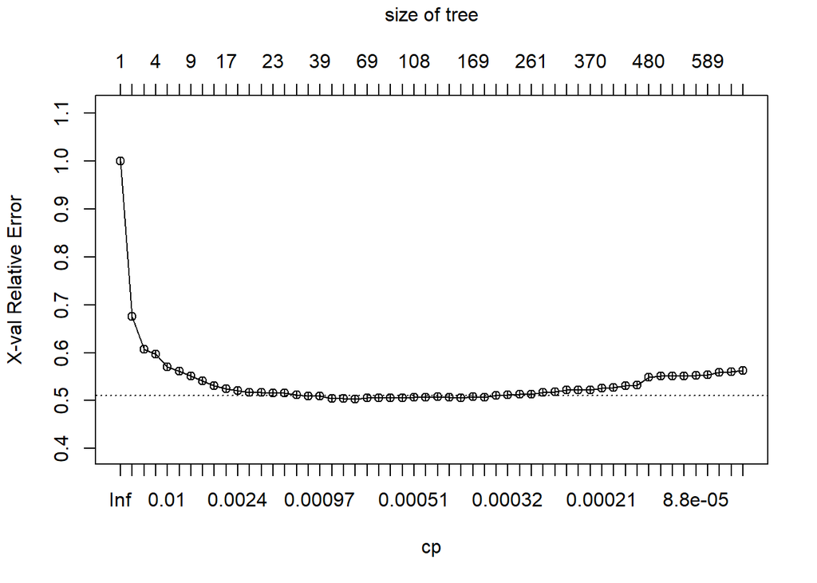

```r
set.seed(42)
full_tree <- rpart(
  loan_status ~ .,
  data = train_set,
  method = "class",
  control = rpart.control(cp = 0) # Allows complex tree to grow
)

plotcp(full_tree)
```

[figure not shown]

```r
# Prune tree with minimum cross-validated error
min_xerror <- full_tree$cptable[which.min(full_tree$cptable[, "xerror"]), ]
min_xerror_tree <- prune(full_tree, cp = min_xerror[1])
rpart.plot(min_xerror_tree, main = "Pruned Classification Tree")
```

```r
test_set$ct_bp_pred_prob <- predict(min_xerror_tree, test_set)[, "Approved"]
test_set$ct_bp_pred_class <- factor(ifelse(test_set$ct_bp_pred_prob > 0.5, "Approved", "Denied"), levels = c("Denied", "Approved"))

cat("Pruned Tree Test Accuracy: ", mean(test_set$ct_bp_pred_class == test_set$loan_status), "\n")
```

```
## Pruned Tree Test Accuracy:  0.7922694
```

## 4.2 Random Forest Tuning

```r
set.seed(42)
res <- tuneRF(
  x = train_set %>% dplyr::select(-loan_status),
  y = train_set$loan_status,
  mtryStart = 2,
  ntreeTry = 200,
  trace = FALSE,
  plot = FALSE
)
```

```
## -0.06475557 0.05
## 0.03634502 0.05
```

```r
best_mtry <- res[which.min(res[, 2]), 1]

rf_best_model <- randomForest(
  loan_status ~ .,
  data = train_set,
  ntree = 500,  #==================Iteration 2===================
  mtry = best_mtry,
  nodesize=5, #iteration #2
  importance = TRUE


)

# 1. Get the raw probabilities
rf_probs <- predict(rf_best_model, test_set, type = "prob")[, "Approved"]

# 2. Build the ROC curve object
rf_roc_obj <- pROC::roc(test_set$loan_status, rf_probs, levels = c("Denied", "Approved"))

# 3. Find the optimal threshold (Youden's Index)
optimal_cut <- pROC::coords(rf_roc_obj, "best", ret="threshold", best.method="youden")
cat("Optimal Probability Threshold for Accuracy is:", optimal_cut$threshold, "\n")
```

```
## Optimal Probability Threshold for Accuracy is: 0.463
```

```r
# 4. Apply the NEW threshold to your test set predictions
test_set$rf_pred_class_optimized <- factor(
  ifelse(rf_probs > optimal_cut$threshold, "Approved", "Denied"),
  levels = c("Denied", "Approved")
)

# 5. Check the new accuracy =========IMPORTANT FOR REVIEW
#Set threshold for classification split is .463 optimal
#standard binary classification model, the default cutoff is usually #$0.50$ (50%). If the model calculates a $\ge 50\%$ probability that #an applicant will be a good loan, it categorizes them as a "Yes." If #it's $< 50\%$, it's a "No

#likely increased your Recall (catching more of the good applicants #who were previously denied) but slightly decreased Precision #(accidentally approving a few more bad ones)

cat("Optimized RF Test Accuracy: ", mean(test_set$rf_pred_class_optimized == test_set$loan_status), "\n")
```

```
## Optimized RF Test Accuracy:  0.8060579
```

```r
test_set$rf_pred_prob <- predict(rf_best_model, test_set, type = "prob")[, "Approved"]
test_set$rf_pred_class <- predict(rf_best_model, test_set, type = "class")

cat("Tuned RF Test Accuracy: ", mean(test_set$rf_pred_class == test_set$loan_status), "\n")
```

```
## Tuned RF Test Accuracy:  0.8060579
```

## 4.3 SVM Tuning

```r
set.seed(42)
svm_tune <- tune(
  svm,
  loan_status ~ .,
  data = train_set,
  kernel = "radial",
  ranges = list(cost = c(0.1, 1, 10))
)

best_svm_mod <- svm_tune$best.model

test_set$svm_bp_pred_class <- predict(best_svm_mod, test_set)
test_set$svm_bp_dv <- as.numeric(attr(predict(best_svm_mod, test_set, decision.values = TRUE), "decision.values"))

cat("Tuned SVM Test Accuracy: ", mean(test_set$svm_bp_pred_class == test_set$loan_status), "\n")
```

```
## Tuned SVM Test Accuracy:  0.7771248
```

```r
#iteration 1: .7402; iteration 2 .777
```

## 4.4 Logistic Regression Tuning (Step-wise)

```r
null_model <- glm(loan_status ~ 1, data = train_set, family = "binomial")
full_model <- logit_model

forward_model <- step(null_model, scope = list(lower = null_model, upper = full_model), direction = "forward", trace = 0)

test_set$logit_step_pred_prob <- predict(forward_model, test_set, type = "response")
test_set$logit_step_pred_class <- factor(ifelse(test_set$logit_step_pred_prob > 0.463, "Approved", "Denied"), levels = c("Denied", "Approved"))


#updated above to .463 iteration 2, iteration 1 .5

cat("Stepwise Logit Test Accuracy: ", mean(test_set$logit_step_pred_class == test_set$loan_status), "\n")
```

```
## Stepwise Logit Test Accuracy:  0.7337251
```

## 4.5 Performance Visualization with ROC

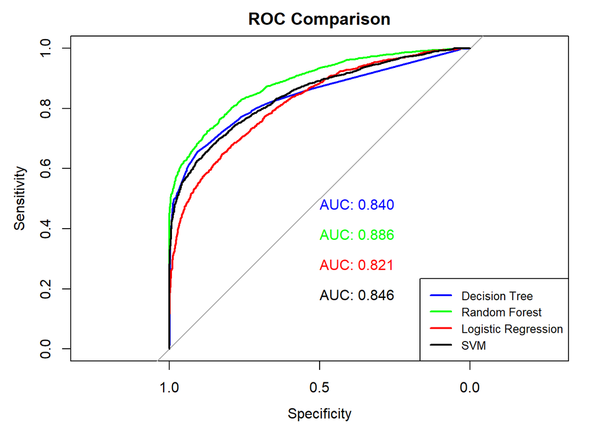

```r
ct_roc <- pROC::roc(test_set$loan_status, test_set$ct_bp_pred_prob, direction = "<", levels = c("Denied", "Approved"), quiet = TRUE)
rf_roc <- pROC::roc(test_set$loan_status, test_set$rf_pred_prob, direction = "<", levels = c("Denied", "Approved"), quiet = TRUE)
logit_roc <- pROC::roc(test_set$loan_status, test_set$logit_step_pred_prob, direction = "<", levels = c("Denied", "Approved"), quiet = TRUE)
svm_roc <- pROC::roc(test_set$loan_status, test_set$svm_bp_dv, direction = "auto", levels = c("Denied", "Approved"), quiet = TRUE)

plot(ct_roc, print.auc = TRUE, col = "blue", main = "ROC Comparison")
plot(rf_roc, print.auc = TRUE, print.auc.y = 0.4, col = "green", add = TRUE)
plot(logit_roc, print.auc = TRUE, print.auc.y = 0.3, col = "red", add = TRUE)
plot(svm_roc, print.auc = TRUE, print.auc.y = 0.2, col = "black", add = TRUE)

legend("bottomright",
  legend = c("Decision Tree", "Random Forest", "Logistic Regression", "SVM"),
  col = c("blue", "green", "red", "black"), lwd = 2, cex = 0.8
)
```

Our high-performance model (Random Forest) generally yields the highest accuracy and encapsulates standard firm approvals accurately. We are now ready to project this understanding onto the manually denied subset.

# M5: Base Case Execution & Deployment

## 5.1 Projecting Scores to Prior Defaulters (The Reconsideration Score)

We will now extract the `df_with_default` group and pass them through our trusted Random Forest to estimate how likely they *would have been* approved if they did not have a prior default. We term this the **Reconsideration Score**.

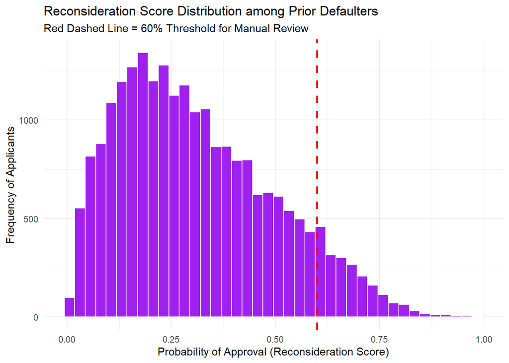

```r
# Apply model to the isolated prior default group
eval_default <- df_with_default %>%
  dplyr::select(-previous_loan_defaults_on_file)
reconsider_probs <- predict(
  rf_best_model,
  newdata = eval_default, type = "prob"
)[, "Approved"]

df_with_default$reconsideration_score <- reconsider_probs

# Plot the distribution of their scores!
ggplot(df_with_default, aes(x = reconsideration_score)) +
  geom_histogram(bins = 40, fill = "purple", color = "white") +
  geom_vline(xintercept = 0.6, linetype = "dashed", color = "red", size = 1) +
  theme_minimal() +
  labs(
    title = "Reconsideration Score Distribution among Prior Defaulters",
    subtitle = "Red Dashed Line = 60% Threshold for Manual Review",
    x = "Probability of Approval (Reconsideration Score)", y = "Frequency of Applicants"
  )
```

## 5.2 Business Outcome: Revenue Identification

If we set a conservative threshold where a score of **60% or greater** kicks the application into a manual review queue, what is the size of that opportunity pool?

```r
threshold <- 0.6
good_candidates <- df_with_default %>% filter(reconsideration_score >= threshold)

# Calculate total impact proportions relative to the entire dataset
total_applicants <- nrow(df_clean)
total_excluded <- nrow(df_with_default)
recons_count <- nrow(good_candidates)

pct_of_excluded <- (recons_count / total_excluded) * 100
pct_of_total <- (recons_count / total_applicants) * 100
potential_loan_volume <- sum(good_candidates$loan_amnt, na.rm = TRUE)

cat(sprintf("Total Historical Applicants Context: %d\n", total_applicants))
```

```
## Total Historical Applicants Context: 44966
```

```r
cat(sprintf("Total Excluded Applicants (Prior Default): %d\n", total_excluded))
```

```
## Total Excluded Applicants (Prior Default): 22841
```

```r
cat(sprintf("Highly Recommend Candidates (>%s Score): %d\n", paste0(threshold * 100, "%"), recons_count))
```

```
## Highly Recommend Candidates (>60% Score): 1981
```

```r
cat("---------\n")
cat(sprintf("Percentage of Excluded that should be manually reviewed: %.2f%%\n", pct_of_excluded))
```

```
## Percentage of Excluded that should be manually reviewed: 8.67%
```

```r
cat(sprintf("Percentage of TOTAL Applicant Pool represented by this cohort: %.2f%%\n", pct_of_total))
```

```
## Percentage of TOTAL Applicant Pool represented by this cohort: 4.41%
```

```r
cat(sprintf("Total Estimated Loan Volume for Reconsideration: $%s\n", format(potential_loan_volume, big.mark = ",")))
```

```
## Total Estimated Loan Volume for Reconsideration: $19,139,684
```

```r
cat("=========\n")
```

```r
# Comparative Descriptive Statistics: Why is this group highly relevant?
# We compare our 60%+ reconsideration group against people who actually got approved historically.
historical_approved <- df_no_default %>% filter(loan_status == "Approved")

comp_stats <- tibble(
  Cohort = c("Historical Approvals", "Recommended for Reconsideration (>60% Score)"),
  Avg_Credit_Score = c(mean(historical_approved$credit_score, na.rm = TRUE), mean(good_candidates$credit_score, na.rm = TRUE)),
  Avg_Income = c(mean(historical_approved$person_income, na.rm = TRUE), mean(good_candidates$person_income, na.rm = TRUE)),
  Avg_Loan_Amount = c(mean(historical_approved$loan_amnt, na.rm = TRUE), mean(good_candidates$loan_amnt, na.rm = TRUE)),
  Avg_Leverage = c(mean(historical_approved$loan_percent_income, na.rm = TRUE), mean(good_candidates$loan_percent_income, na.rm = TRUE))
)

knitr::kable(comp_stats, digits = 2, caption = "Relevance: Comparing Reconsideration Candidates to Typical Approvals")
```

Relevance: Comparing Reconsideration Candidates to Typical Approvals

[output not shown]

```r
# Sample of these premium candidates
good_candidates %>%
  dplyr::select(person_income, loan_amnt, loan_percent_income, credit_score, reconsideration_score) %>%
  head(100) %>%
  knitr::kable(digits = 2, caption = "Sample of Top Tier 'Prior Default' Candidates Recommended for Review")
```

Sample of Top Tier ‘Prior Default’ Candidates Recommended for Review

| person_income | loan_amnt | loan_percent_income | credit_score | reconsideration_score |
| --- | --- | --- | --- | --- |
| 600891 | 30000 | 0.05 | 670 | 0.63 |
| 368115 | 24250 | 0.07 | 567 | 0.64 |
| 182316 | 28000 | 0.15 | 634 | 0.64 |
| 277017 | 35000 | 0.13 | 622 | 0.67 |
| 258980 | 35000 | 0.14 | 618 | 0.69 |
| 222975 | 25000 | 0.11 | 593 | 0.67 |
| 220872 | 20000 | 0.09 | 504 | 0.66 |
| 100435 | 25000 | 0.25 | 576 | 0.78 |
| 103400 | 25000 | 0.24 | 592 | 0.70 |
| 105349 | 25000 | 0.24 | 621 | 0.67 |
| 111490 | 25000 | 0.22 | 622 | 0.69 |
| 19175 | 1750 | 0.09 | 587 | 0.68 |
| 19158 | 1750 | 0.09 | 625 | 0.61 |
| 19169 | 1500 | 0.08 | 537 | 0.62 |
| 163683 | 25000 | 0.15 | 582 | 0.63 |
| 20401 | 2275 | 0.11 | 573 | 0.72 |
| 193337 | 35000 | 0.18 | 602 | 0.66 |
| 102011 | 24500 | 0.24 | 627 | 0.61 |
| 123299 | 23600 | 0.19 | 555 | 0.62 |
| 85496 | 21000 | 0.25 | 614 | 0.87 |
| 90944 | 21000 | 0.23 | 523 | 0.62 |
| 24521 | 7500 | 0.31 | 612 | 0.76 |
| 24993 | 16600 | 0.66 | 634 | 0.67 |
| 24853 | 7125 | 0.29 | 631 | 0.64 |
| 24853 | 2500 | 0.10 | 524 | 0.64 |
| 24751 | 3600 | 0.15 | 669 | 0.67 |
| 25229 | 7000 | 0.28 | 626 | 0.63 |
| 81580 | 20000 | 0.25 | 607 | 0.92 |
| 85061 | 20000 | 0.24 | 627 | 0.67 |
| 86325 | 20000 | 0.23 | 566 | 0.63 |

[output cut: 70 more lines]

## M5 Context: Unsupervised Cross-Validation (Clustering)

To provide another “expert eye” on these candidates, how do they group without any target variables at all?

```r
# We scale the financial health attributes of all applicants
cluster_vars <- df_clean %>%
  dplyr::select(loan_percent_income, credit_score, person_income) %>%
  drop_na()
cluster_scaled <- scale(cluster_vars)

# Form 3 KMeans clusters
km <- kmeans(cluster_scaled, centers = 3, nstart = 25)

cluster_summary <- cluster_vars %>%
  mutate(Cluster = as.factor(km$cluster)) %>%
  group_by(Cluster) %>%
  summarise(
    Mean_Credit = mean(credit_score),
    Mean_Income = mean(person_income),
    Mean_Leverage = mean(loan_percent_income),
    Count = n()
  )

knitr::kable(cluster_summary, caption = "Unsupervised Cluster Averages")
```

Unsupervised Cluster Averages

| Cluster | Mean_Credit | Mean_Income | Mean_Leverage | Count |
| --- | --- | --- | --- | --- |
| 1 | 661.6684 | 95558.28 | 0.0913231 | 21042 |
| 2 | 571.9636 | 75775.28 | 0.1169166 | 12428 |
| 3 | 644.8793 | 53711.36 | 0.2533142 | 11496 |

# Conclusion & Deployment Plan

**Proxy Target Classification**, we built a model to emulate standard approval operations and systematically screened the definitively denied group to surface high-potential candidates.

**Deployment Consideration:** - Instead of auto-denying 100% of applicants with a prior default, the system should invoke an API call generating the `reconsideration_score`. - If the score > 0.60, the application is flagged as “Pending - Manual Review”.

**Hazards & Bias:** While these individuals show currently strong financial positioning, their prior default remains a material fact. Manual review procedures should involve human verification of *why* the prior default occurred. Models cannot quantify sudden macroeconomic shocks to prior defaulting individuals; thus humans remain the best mitigation strategy before the firm releases capital.